Le Pool de la Grande Soirée Propulsé par le CAPP Université Laval · Québec

Lundi 5 octobre 2026 Amphithéâtre Hydro-Québec, pavillon Alphonse-Desjardins. Salle comble : les 200 billets ont trouvé preneur.

Les résultats du défi de pronostics

# Le Pool de la Grande Soirée

Québec 2026

Cinquième édition · Les résultats

Le Parti québécois forme un gouvernement minoritaire avec 59 sièges. 63 pools, deux prix : voici qui a vu juste.

Pool fermé le 5 octobre à 20h **63 pronostics retenus** Résultats finaux d'Élections Québec **6 octobre 2026**

01

## Le résultat

Résultats finaux d'Élections Québec, 127 circonscriptions sur 127, publiés le 6 octobre. La majorité était à 64.

[figure not shown]

PQ59PLQ40PCQ19QS9CAQ0

Le **PQ** forme un gouvernement minoritaire avec 59 sièges.

**Votes**

PQ 28,02 %, PLQ 24,22 %, PCQ 20,67 %, CAQ 13,35 %, QS 12,42 %.

**Participation**

66,92 %.

**Défi 1**

Christine Fréchette gagne-t-elle Trois-Rivières? **Non.** Le PQ l'emporte, et la CAQ n'a aucun siège.

**Défi 2**

Le parti en tête dans la Capitale-Nationale : **le PCQ**, 8 circonscriptions sur 11.

**Défi 3**

Le deuxième en votes : **le PLQ**.

**Bris d'égalité**

Radio-Canada a annoncé le gouvernement péquiste vers **20h37**.

02

## Les gagnants

Le Grand Devin va au plus petit score. Le Cartographe, au plus grand nombre de circonscriptions justes en mode expert. Une personne, un prix.

🏆 Le Grand Devin Jules Piral -2 points 4 sièges d'écart en tout et les trois défis réussis. En mode expert, 117 circonscriptions justes sur 127. PQ · PLQ · PCQ · QS · CAQ  
57 · 41 · 20 · 9 · 0

🗺️ Le Cartographe Les Westbury Acadians 116 / 127 116 circonscriptions justes, et 4 sièges d'écart en tout. Jules Piral en avait 117, mais une personne ne repart qu'avec un prix. PQ · PLQ · PCQ · QS · CAQ  
58 · 39 · 20 · 9 · 1

Les deux gagnants sont joints par courriel pour la remise des prix.

03

## Le classement

Les 63 pools, du plus petit score au plus grand. Les égalités sont départagées par l'écart à l'heure d'annonce, puis par l'écart au taux de participation.

| Rang | Nom | Pronostic PQ · PLQ · PCQ · QS · CAQ | Écart | Défis | Score | Circ. justes |
| --- | --- | --- | --- | --- | --- | --- |
| 1 | Jules Piral expert57 · 41 · 20 · 9 · 0 | 57 · 41 · 20 · 9 · 0 | 4 | 3/3 | -2 | 117/127 |
| 2 | Guillaume Lachance61 · 39 · 20 · 7 · 0 | 61 · 39 · 20 · 7 · 0 | 6 | 3/3 | 0 |  |
| 3 | Les Westbury Acadians expert58 · 39 · 20 · 9 · 1 | 58 · 39 · 20 · 9 · 1 | 4 | 2/3 | 0 | 116/127 |
| 4 | Félix Tanguay60 · 40 · 20 · 6 · 1 | 60 · 40 · 20 · 6 · 1 | 6 | 2/3 | 2 |  |
| 5 | Joelle63 · 38 · 17 · 9 · 0 | 63 · 38 · 17 · 9 · 0 | 8 | 3/3 | 2 |  |
| 6 | Vincent M.62 · 40 · 20 · 5 · 0 | 62 · 40 · 20 · 5 · 0 | 8 | 3/3 | 2 |  |
| 7 | Yannick Dufresne61 · 39 · 16 · 9 · 2 | 61 · 39 · 16 · 9 · 2 | 8 | 3/3 | 2 |  |
| 8 | Manuel Q expert56 · 38 · 22 · 11 · 0 | 56 · 38 · 22 · 11 · 0 | 10 | 3/3 | 4 | 112/127 |
| 9 | Matheo.M expert60 · 38 · 18 · 7 · 4 | 60 · 38 · 18 · 7 · 4 | 10 | 3/3 | 4 | 109/127 |
| 10 | Charlie G61 · 40 · 16 · 8 · 2 | 61 · 40 · 16 · 8 · 2 | 8 | 2/3 | 4 |  |
| 11 | Luca HUGUENOTTE59 · 42 · 22 · 4 · 0 | 59 · 42 · 22 · 4 · 0 | 10 | 3/3 | 4 |  |
| 12 | Florence Méthot59 · 37 · 20 · 8 · 3 | 59 · 37 · 20 · 8 · 3 | 8 | 2/3 | 4 |  |
| 13 | Séverine Cossette63 · 38 · 15 · 9 · 2 | 63 · 38 · 15 · 9 · 2 | 12 | 3/3 | 6 |  |
| 14 | Patricia C. expert62 · 40 · 16 · 7 · 2 | 62 · 40 · 16 · 7 · 2 | 10 | 2/3 | 6 | 106/127 |
| 15 | Alexis Desnoyers Muckle expert65 · 37 · 17 · 8 · 0 | 65 · 37 · 17 · 8 · 0 | 12 | 3/3 | 6 | 114/127 |
| 16 | Hubert Cadieux63 · 37 · 18 · 7 · 2 | 63 · 37 · 18 · 7 · 2 | 12 | 3/3 | 6 |  |
| 17 | Alicia Durocher62 · 37 · 15 · 12 · 1 | 62 · 37 · 15 · 12 · 1 | 14 | 3/3 | 8 |  |
| 18 | Shawn Philip66 · 35 · 17 · 9 · 0 | 66 · 35 · 17 · 9 · 0 | 14 | 3/3 | 8 |  |
| 19 | Diva61 · 35 · 20 · 8 · 3 | 61 · 35 · 20 · 8 · 3 | 12 | 2/3 | 8 |  |
| 20 | Joelle C.58 · 37 · 16 · 14 · 2 | 58 · 37 · 16 · 14 · 2 | 14 | 3/3 | 8 |  |
| 21 | Alexis L.66 · 37 · 17 · 7 · 0 | 66 · 37 · 17 · 7 · 0 | 14 | 3/3 | 8 |  |
| 22 | Elliot Marchand64 · 35 · 19 · 7 · 2 | 64 · 35 · 19 · 7 · 2 | 14 | 3/3 | 8 |  |
| 23 | Philippe Léonard-Dufour67 · 36 · 16 · 8 · 0 | 67 · 36 · 16 · 8 · 0 | 16 | 3/3 | 10 |  |
| 24 | Eliot59 · 34 · 22 · 9 · 3 | 59 · 34 · 22 · 9 · 3 | 12 | 1/3 | 10 |  |
| 25 | Thomas Lefebvre65 · 37 · 15 · 8 · 2 | 65 · 37 · 15 · 8 · 2 | 16 | 3/3 | 10 |  |
| 26 | Olivier Caron67 · 37 · 16 · 7 · 0 | 67 · 37 · 16 · 7 · 0 | 16 | 3/3 | 10 |  |
| 27 | Loïka Desmeules61 · 36 · 20 · 6 · 4 | 61 · 36 · 20 · 6 · 4 | 14 | 2/3 | 10 |  |
| 28 | Hugo58 · 37 · 14 · 10 · 8 | 58 · 37 · 14 · 10 · 8 | 18 | 2/3 | 14 |  |
| 29 | Emma Toader66 · 38 · 14 · 7 · 2 | 66 · 38 · 14 · 7 · 2 | 18 | 2/3 | 14 |  |
| 30 | Alexandre Fortier-Chouinard65 · 34 · 17 · 8 · 3 | 65 · 34 · 17 · 8 · 3 | 18 | 2/3 | 14 |  |
| 31 | Julie Gouin expert69 · 36 · 13 · 9 · 0 | 69 · 36 · 13 · 9 · 0 | 20 | 3/3 | 14 | 112/127 |
| 32 | Joanny Drouin63 · 33 · 15 · 10 · 6 | 63 · 33 · 15 · 10 · 6 | 22 | 3/3 | 16 |  |
| 33 | Frederic Hengartner69 · 35 · 13 · 10 · 0 | 69 · 35 · 13 · 10 · 0 | 22 | 3/3 | 16 |  |
| 34 | Mikaël G.68 · 37 · 13 · 7 · 2 | 68 · 37 · 13 · 7 · 2 | 22 | 3/3 | 16 |  |
| 35 | Caroline Atchadé65 · 38 · 11 · 8 · 5 | 65 · 38 · 11 · 8 · 5 | 22 | 3/3 | 16 |  |
| 36 | Laurie Lavoie63 · 30 · 22 · 9 · 3 | 63 · 30 · 22 · 9 · 3 | 20 | 2/3 | 16 |  |
| 37 | Dominic Gaudette61 · 29 · 25 · 9 · 3 | 61 · 29 · 25 · 9 · 3 | 22 | 3/3 | 16 |  |
| 38 | The wolf66 · 33 · 17 · 6 · 5 | 66 · 33 · 17 · 6 · 5 | 24 | 3/3 | 18 |  |
| 39 | Dany Clouâtre expert72 · 35 · 14 · 6 · 0 | 72 · 35 · 14 · 6 · 0 | 26 | 3/3 | 20 | 112/127 |
| 40 | Alexandre Côté64 · 30 · 25 · 6 · 2 | 64 · 30 · 25 · 6 · 2 | 26 | 3/3 | 20 |  |
| 41 | Kevin Tanguay-Dubé70 · 30 · 15 · 9 · 3 | 70 · 30 · 15 · 9 · 3 | 28 | 3/3 | 22 |  |
| 42 | Morgan Le bos67 · 26 · 23 · 9 · 2 | 67 · 26 · 23 · 9 · 2 | 28 | 3/3 | 22 |  |
| 43 | Boulet63 · 35 · 14 · 7 · 6 · 2 autres | 63 · 35 · 14 · 7 · 6 · 2 autres | 24 | 1/3 | 22 |  |
| 44 | Gabriel64 · 37 · 12 · 7 · 7 | 64 · 37 · 12 · 7 · 7 | 24 | 1/3 | 22 |  |
| 45 | Marie Emilie56 · 35 · 14 · 10 · 11 · 1 autres | 56 · 35 · 14 · 10 · 11 · 1 autres | 26 | 2/3 | 22 |  |
| 46 | Marc-Antoine Dupuis59 · 35 · 14 · 6 · 13 | 59 · 35 · 14 · 6 · 13 | 26 | 1/3 | 24 |  |
| 47 | Alexandre Gajevic56 · 38 · 11 · 10 · 12 | 56 · 38 · 11 · 10 · 12 | 26 | 1/3 | 24 |  |
| 48 | C-D Laflamme69 · 32 · 12 · 13 · 1 | 69 · 32 · 12 · 13 · 1 | 30 | 2/3 | 26 |  |
| 49 | Lucie63 · 27 · 25 · 7 · 2 · 3 autres | 63 · 27 · 25 · 7 · 2 · 3 autres | 30 | 2/3 | 26 |  |
| 50 | Jean-Thomas Perreault60 · 32 · 12 · 11 · 6 · 6 autres | 60 · 32 · 12 · 11 · 6 · 6 autres | 30 | 2/3 | 26 |  |
| 51 | Marc52 · 34 · 28 · 6 · 7 | 52 · 34 · 28 · 6 · 7 | 32 | 2/3 | 28 |  |
| 52 | Victor Legault expert74 · 33 · 13 · 5 · 2 | 74 · 33 · 13 · 5 · 2 | 34 | 3/3 | 28 | 108/127 |
| 53 | SaLaj65 · 37 · 5 · 15 · 5 | 65 · 37 · 5 · 15 · 5 | 34 | 2/3 | 30 |  |
| 54 | Justine Blondeau65 · 23 · 25 · 9 · 5 | 65 · 23 · 25 · 9 · 5 | 34 | 1/3 | 32 |  |
| 55 | Lei Anne L.52 · 30 · 35 · 10 · 0 | 52 · 30 · 35 · 10 · 0 | 34 | 1/3 | 32 |  |
| 56 | Morgan64 · 28 · 11 · 10 · 14 | 64 · 28 · 11 · 10 · 14 | 40 | 2/3 | 36 |  |
| 57 | Vanessa Trottier-Michaud40 · 40 · 34 · 10 · 3 | 40 · 40 · 34 · 10 · 3 | 38 | 1/3 | 36 |  |
| 58 | Olivier Simard58 · 21 · 36 · 12 · 0 | 58 · 21 · 36 · 12 · 0 | 40 | 2/3 | 36 |  |
| 59 | Juliane56 · 33 · 10 · 11 · 17 | 56 · 33 · 10 · 11 · 17 | 38 | 1/3 | 36 |  |
| 60 | PP65 · 33 · 3 · 16 · 10 | 65 · 33 · 3 · 16 · 10 | 46 | 2/3 | 42 |  |
| 61 | Félix Paradis52 · 25 · 26 · 6 · 18 | 52 · 25 · 26 · 6 · 18 | 50 | 1/3 | 48 |  |
| 62 | DrFrenchie48 · 26 · 20 · 13 · 16 · 4 autres | 48 · 26 · 20 · 13 · 16 · 4 autres | 50 | 0/3 | 50 |  |
| 63 | Arianne Lévesque39 · 25 · 29 · 12 · 22 | 39 · 25 · 29 · 12 · 22 | 70 | 1/3 | 68 |  |

04

## Comment le score est calculé

1. Le score additionne, parti par parti, l'**écart** entre les sièges prédits et les sièges obtenus.
2. Chaque **défi réussi** retranche 2 points. Il y en avait trois : Christine Fréchette dans Trois-Rivières, le parti en tête dans la Capitale-Nationale, le deuxième en votes. En mode expert, les deux premiers se lisent dans la grille des 127.
3. **Le plus petit score gagne** le Grand Devin. Le plus grand nombre de circonscriptions justes, en mode expert, gagne le Cartographe. Une personne, un prix.
4. Les égalités sont départagées par l'heure d'annonce de Radio-Canada (20h37), puis par le taux de participation (66,92 %).

67 pools reçus, 63 retenus : 2 essais de l'équipe et 2 envois en double, dont seul le dernier compte.

Centre d'analyse des politiques publiques · Université Laval

## En savoir plus sur les projets du CAPP

Tous accessibles en ligne, gratuitement.

[figure not shown]

Le CAPP Le centre de recherche qui abrite ces projets. capp-ulaval.ca

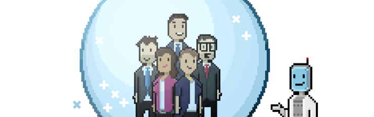

Le Défi Datagotchi Un questionnaire sur le style de vie, et le modèle prédit ensuite pour qui on vote. quebec.datagotchi.com

[figure not shown]

Le Prof. Datagotchi Un agent conversationnel qui a écouté 285 entrevues, balados et conférences de presse des cinq partis. Il répond à partir de leurs propres mots, sources à l'appui. prof-datagotchi.com

[figure not shown]

La Vitrine démocratique Ce dont les médias québécois parlent en ce moment, mesuré à chaque heure : la Une des Unes, les douze enjeux, la couverture de chaque parti. vitrinedemocratique.com [Polimètre Le Polimètre Le suivi des promesses d'un gouvernement, une par une : tenues, brisées ou en attente. polimetre.org](https://www.polimetre.org/fr)

[figure not shown]

L'EIOM L'École interdisciplinaire outils & méthodes. Cinq jours de formation méthodologique chaque mois d'août à l'Université Laval. eiom.ca

Partenaires

### La soirée

[figure not shown]

[figure not shown]

[figure not shown]

[figure not shown]

[figure not shown]

Avec le [Département de science politique](https://www.pol.ulaval.ca/) de l'Université Laval et [PARDUR](https://www.ulaval.ca/la-recherche/unites-de-recherche/laboratoires-internationaux-associes/laboratoire-international-associe-partis-representations-politiques-et-developpement-durable-pardur-lia), le laboratoire international associé sur les partis, les représentations politiques et le développement durable.

### Nos projets

[figure not shown]

[figure not shown]

[figure not shown]

[figure not shown]

[figure not shown]